# Fitting the ST model for the LUR

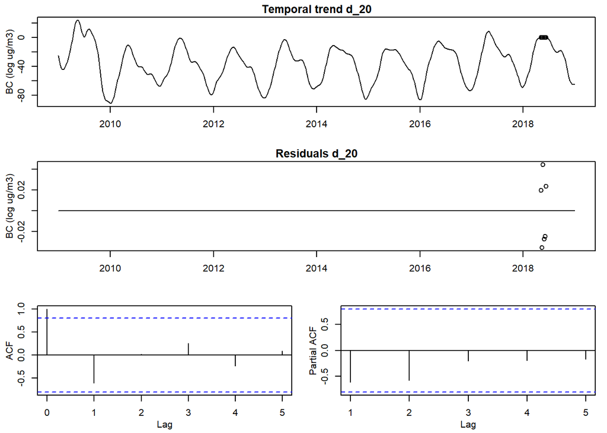

```r
par(mar=c(3.3,3.3,1.5,1), mgp=c(2,1,0))
layout(matrix(c(1,1,2,2,3,4), 3, 2, byrow=TRUE))
plot(denver.data2.2a, "obs", ID="d_20", xlab="", ylab="BC (log ug/m3)",
     main="Temporal trend d_20")
plot(denver.data2.2a, "res", ID="d_20", xlab="", ylab="BC (log ug/m3)")
plot(denver.data2.2a, "acf", ID="d_20")
plot(denver.data2.2a, "pacf", ID="d_20")
```

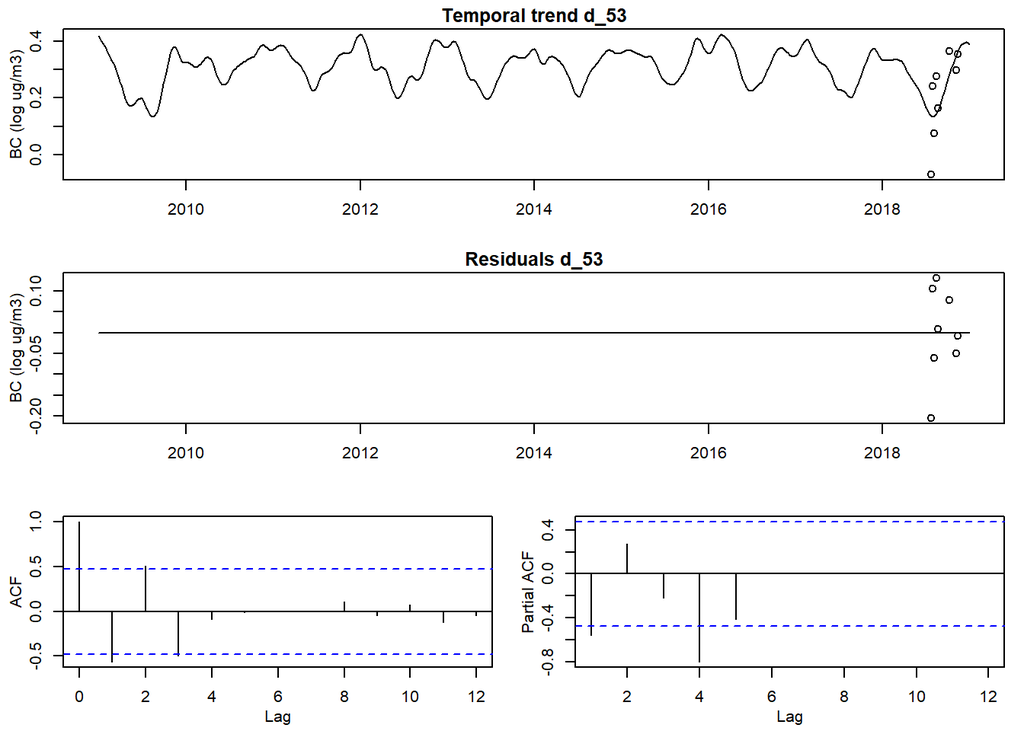

```r
par(mar=c(3.3,3.3,1.5,1), mgp=c(2,1,0))
layout(matrix(c(1,1,2,2,3,4), 3, 2, byrow=TRUE))
plot(denver.data2.2a, "obs", ID="d_53", xlab="", ylab="BC (log ug/m3)",
     main="Temporal trend d_53")
plot(denver.data2.2a, "res", ID="d_53", xlab="", ylab="BC (log ug/m3)")
plot(denver.data2.2a, "acf", ID="d_53")
plot(denver.data2.2a, "pacf", ID="d_53")
```

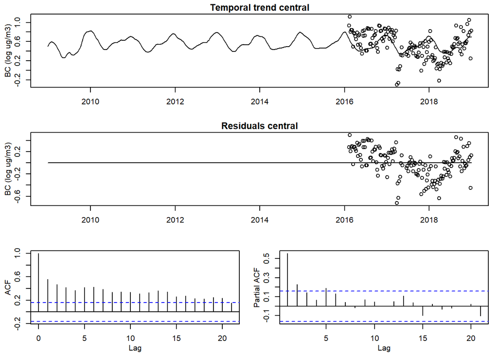

```r
par(mar=c(3.3,3.3,1.5,1), mgp=c(2,1,0))
layout(matrix(c(1,1,2,2,3,4), 3, 2, byrow=TRUE))
plot(denver.data2.2a, "obs", ID="central", xlab="", ylab="BC (log ug/m3)",
     main="Temporal trend central")
plot(denver.data2.2a, "res", ID="central", xlab="", ylab="BC (log ug/m3)")
plot(denver.data2.2a, "acf", ID="central")
plot(denver.data2.2a, "pacf", ID="central")
```

# 3 Testing possible models

Building on the results of the previous modeling efforts, I’m going to update “Model 4.2”, which used an ’`exp` covariance structure for the error term and `iid` for the beta fields.

## 3.1 Model A: 1 temporal trend (basis) function

### 3.1.1 Create the model object

For this version of the model, use `iid` for `cov.beta` (beta, beta1) and `exp` for `cov.nu` (error). Here we can specify different LUR formluae. The length of the LUR list should be number of basis functions + 1.

```r
denver.data.A <- denver.data2.1
names(denver.data.A$covars)
```

```
##  [1] "ID"                  "lon"                 "lat"
##  [4] "impervious_2500"     "open_2500"           "low_int_100"
##  [7] "med_int_50"          "high_int_50"         "high_int_100"
## [10] "ag_250"              "pop_den_50"          "dist_m_compost"
## [13] "dist_m_military"     "len_m_highways_2500" "aadt_100"
## [16] "aadt_2500"           "x"                   "y"
## [19] "type"
```

```r
LUR.A <- list(covar_fun, covar_fun)

cov.beta.A <-  list(covf = c("iid", "iid"), nugget = T)
cov.nu.A <- list(covf = "exp", nugget = T, random.effect = FALSE)
locations.A <- list(coords = c("x","y"), long.lat = c("lon","lat"), others= "type")

denver.model.A <- createSTmodel(denver.data.A, LUR = LUR.A,
                                ST = c("bc_st_no2", "bc_st_smk"),
                                cov.beta = cov.beta.A, cov.nu = cov.nu.A,
                                locations = locations.A)
```

```
## No trend $trend.fnc object detected, STdata probably from old version of the package.
## $trend.fnc has been added based on spline fit to elements in STmodel$trend.
```

```r
denver.model.A
```

```
## STmodel-object with:
##  No. locations: 61 (observed: 61)
##  No. time points: 521 (observed: 148)
##  No. obs: 763
##
## Trend with 1 basis function(s):
## [1] "V1"
## with dates:
##  2008-12-29 to 2018-12-31
##
## Models for the beta-fields are:
## $const
## ~~impervious_2500 + open_2500 + low_int_100 + med_int_50 + high_int_50 +
##     high_int_100 + ag_250 + pop_den_50 + dist_m_compost + dist_m_military +
##     len_m_highways_2500 + aadt_100 + aadt_2500
##
## $V1
## ~~impervious_2500 + open_2500 + low_int_100 + med_int_50 + high_int_50 +
##     high_int_100 + ag_250 + pop_den_50 + dist_m_compost + dist_m_military +
##     len_m_highways_2500 + aadt_100 + aadt_2500
##
## 2 spatio-temporal covariate(s):
## [1] "bc_st_no2" "bc_st_smk"
##
## Covariance model for the beta-field(s):
##  Covariance type(s): iid, iid
##  Nugget: Yes, Yes
## Covariance model for the nu-field(s):
##  Covariance type: exp
##  Nugget: ~1
##  Random effect: No
## All sites:
## central    dist
##       1      60
## Observed:
## central    dist
##       1      60
##
## For central:
##   Number of obs: 148
##   Dates: 2016-02-08 to 2018-12-31
## For dist:
##   Number of obs: 615
##   Dates: 2018-05-07 to 2018-11-12
```

### 3.1.2 Estimate model parameters

- nugget values can range from -1 to -6
- range values can range from 0 to 4
- try starting values where the sill and nugget are the same (e.g., both 0) and where they are very different (e.g., 0 and -5)
- make sure the starting values are pretty different

```r
names <- loglikeSTnames(denver.model.A, all=FALSE)
names
```

```
## [1] "log.nugget.const.iid"          "log.nugget.V1.iid"
## [3] "nu.log.range.exp"              "nu.log.sill.exp"
## [5] "nu.log.nugget.(Intercept).exp"
```

```r
# x.init.A <- cbind(c(0, 0, 0, 0, 0),
#                   c(-1, -1, 0, -1, -1),
#                   c(-1, -1, 0, -5, -1),
#                   c(-5, -5, 0, -1, -5),
#                   c(-5, -5, 0, -5, -5),
#                   c(-1, -1, 2, -1, -1),
#                   c(-1, -1, 2, -5, -1),
#                   c(-5, -5, 2, -1, -5),
#                   c(-5, -5, 2, -5, -5),
#                   c(-1, -1, 4, -1, -1),
#                   c(-1, -1, 4, -5, -1),
#                   c(-5, -5, 4, -1, -5),
#                   c(-5, -5, 4, -5, -5))

x.init.A <- cbind(c(0, 0, 0, 0, 0),
                  c(-1, -1, 4, -5, -1),
                  c(-5, -5, 4, -1, -5),
                  c(-1, -1, 8, -5, -1),
                  c(-5, -5, 8, -1, -5),
                  c(-1, -1, 12, -5, -1),
                  c(-5, -5, 12, -1, -5))

rownames(x.init.A) <- loglikeSTnames(denver.model.A, all=FALSE)
x.init.A
```

```
##                               [,1] [,2] [,3] [,4] [,5] [,6] [,7]
## log.nugget.const.iid             0   -1   -5   -1   -5   -1   -5
## log.nugget.V1.iid                0   -1   -5   -1   -5   -1   -5
## nu.log.range.exp                 0    4    4    8    8   12   12
## nu.log.sill.exp                  0   -5   -1   -5   -1   -5   -1
## nu.log.nugget.(Intercept).exp    0   -1   -5   -1   -5   -1   -5
```

```r
#' Difference from tutorial: use Josh Keller's version of the function
source(here::here("Code", "functions_model.R"))
est.denver.model.A <- estimate.STmodel(denver.model.A, x.init.A)
```

```
## Optimisation using starting value 1/7
```

```
## N = 5, M = 5 machine precision = 2.22045e-16
## At X0, 0 variables are exactly at the bounds
## At iterate     0  f=       356.85  |proj g|=           15
## At iterate    10  f =      -1086.4  |proj g|=        1.5534
## At iterate    20  f =      -1086.5  |proj g|=     0.0063686
##
## iterations 22
## function evaluations 25
## segments explored during Cauchy searches 26
## BFGS updates skipped 0
## active bounds at final generalized Cauchy point 1
## norm of the final projected gradient 0.000981342
## final function value -1086.55
##
## F = -1086.55
```

```
## Optimisation using starting value 2/7
```

```
## N = 5, M = 5 machine precision = 2.22045e-16
## At X0, 0 variables are exactly at the bounds
## At iterate     0  f=      -235.61  |proj g|=           14
## At iterate    10  f =      -1085.6  |proj g|=        2.3211
## At iterate    20  f =      -1086.7  |proj g|=       0.14236
## ys=-1.748e-01  -gs= 1.135e-01, BFGS update SKIPPED
## At iterate    30  f =      -1295.6  |proj g|=        9.4245
## At iterate    40  f =      -1419.3  |proj g|=       0.13736
##
## iterations 44
## function evaluations 73
## segments explored during Cauchy searches 48
## BFGS updates skipped 1
## active bounds at final generalized Cauchy point 1
## norm of the final projected gradient 0.000135154
## final function value -1419.27
##
## F = -1419.27
```

```
## Optimisation using starting value 3/7
```

```
## N = 5, M = 5 machine precision = 2.22045e-16
## At X0, 0 variables are exactly at the bounds
## At iterate     0  f=      -351.69  |proj g|=           14
## At iterate    10  f =      -1085.8  |proj g|=        1.1748
## At iterate    20  f =      -1086.6  |proj g|=       0.05939
## ys=-1.430e-03  -gs= 1.890e-02, BFGS update SKIPPED
## At iterate    30  f =        -1273  |proj g|=        18.657
## At iterate    40  f =      -1398.2  |proj g|=        0.2973
## At iterate    50  f =      -1412.6  |proj g|=        9.6706
## At iterate    60  f =      -1419.3  |proj g|=      0.029135
##
## iterations 60
## function evaluations 103
## segments explored during Cauchy searches 62
## BFGS updates skipped 1
## active bounds at final generalized Cauchy point 1
## norm of the final projected gradient 0.0291353
## final function value -1419.27
##
## F = -1419.27
```

```
## Optimisation using starting value 4/7
```

```
## N = 5, M = 5 machine precision = 2.22045e-16
## At X0, 0 variables are exactly at the bounds
## At iterate     0  f=      -235.75  |proj g|=           14
## At iterate    10  f =      -1360.6  |proj g|=       0.15031
## At iterate    20  f =      -1418.4  |proj g|=        3.3011
##
## iterations 27
## function evaluations 44
## segments explored during Cauchy searches 30
## BFGS updates skipped 0
## active bounds at final generalized Cauchy point 1
## norm of the final projected gradient 0.0490261
## final function value -1419.27
##
## F = -1419.27
```

```
## Optimisation using starting value 5/7
```

```
## N = 5, M = 5 machine precision = 2.22045e-16
## At X0, 0 variables are exactly at the bounds
## At iterate     0  f=      -416.99  |proj g|=           14
## At iterate    10  f =      -1419.1  |proj g|=        2.9455
##
## iterations 19
## function evaluations 25
## segments explored during Cauchy searches 21
## BFGS updates skipped 0
## active bounds at final generalized Cauchy point 1
## norm of the final projected gradient 0.000537303
## final function value -1419.27
##
## F = -1419.27
```

```
## Optimisation using starting value 6/7
```

```
## N = 5, M = 5 machine precision = 2.22045e-16
## At X0, 0 variables are exactly at the bounds
## At iterate     0  f=      -237.86  |proj g|=           14
## At iterate    10  f =      -1419.1  |proj g|=        3.3067
##
## iterations 17
## function evaluations 23
## segments explored during Cauchy searches 20
## BFGS updates skipped 0
## active bounds at final generalized Cauchy point 1
## norm of the final projected gradient 0.0746266
## final function value -1419.27
##
## F = -1419.27
```

```
## Optimisation using starting value 7/7
```

```
## N = 5, M = 5 machine precision = 2.22045e-16
## At X0, 0 variables are exactly at the bounds
## At iterate     0  f=      -1057.7  |proj g|=           14
## At iterate    10  f =      -1419.3  |proj g|=       0.23375
##
## iterations 15
## function evaluations 31
## segments explored during Cauchy searches 19
## BFGS updates skipped 0
## active bounds at final generalized Cauchy point 1
## norm of the final projected gradient 0.00802183
## final function value -1419.27
##
## F = -1419.27
## l(0) > u(0).  No feasible solutionfinal  value -1419.270576
```

```r
print(est.denver.model.A)
```

```
## Optimisation for STmodel with 7 starting points.
##   Results: 6 converged, 1 not converged, 0 failed.
##   Best result for starting point 6, optimisation has converged
##
## No fixed parameters.
##
## Estimated parameters for all starting point(s):
##                                          [,1]          [,2]          [,3]
## gamma.bc_st_no2                   0.023847073  0.0198075401  0.0198084531
## gamma.bc_st_smk                   0.024972681  0.0085130334  0.0085167912
## alpha.const.(Intercept)          -0.249661732 -0.1984200936 -0.1984436907
## alpha.const.impervious_2500       0.004330993  0.0027365258  0.0027341354
## alpha.const.open_2500            -0.046095241 -0.0376613885 -0.0376612043
## alpha.const.low_int_100          -0.006672407  0.0015513672  0.0015521153
## alpha.const.med_int_50           -0.006993224  0.0028027953  0.0028020342
## alpha.const.high_int_50           0.023362684  0.0318159535  0.0318166664
## alpha.const.high_int_100         -0.003245918 -0.0276941135 -0.0276943828
## alpha.const.ag_250                0.015050374  0.0143323658  0.0143327680
## alpha.const.pop_den_50           -0.007777724 -0.0052995513 -0.0052979652
## alpha.const.dist_m_compost       -0.022811890 -0.0251219649 -0.0251213760
## alpha.const.dist_m_military       0.002894913 -0.0048389231 -0.0048391058
## alpha.const.len_m_highways_2500  -0.005207071 -0.0025225626 -0.0025213371
## alpha.const.aadt_100              0.019456586  0.0419812596  0.0419822297
## alpha.const.aadt_2500             0.011125868  0.0065512745  0.0065517948
## alpha.V1.(Intercept)              0.123991376  0.0105419560  0.0105353022
## alpha.V1.impervious_2500          0.014803583  0.0112367166  0.0112329709
## alpha.V1.open_2500                0.005125775  0.0030316369  0.0030248996
## alpha.V1.low_int_100             -0.007278731 -0.0004200256 -0.0004217656
## alpha.V1.med_int_50              -0.006010489  0.0016525812  0.0016506587
## alpha.V1.high_int_50             -0.018455396 -0.0013470131 -0.0013470759
## alpha.V1.high_int_100             0.053555180  0.0294598679  0.0294579396
## alpha.V1.ag_250                   0.013995685 -0.0001440423 -0.0001462048
## alpha.V1.pop_den_50               0.012397406 -0.0023050799 -0.0023058750
## alpha.V1.dist_m_compost           0.017261188  0.0028936071  0.0028884758
## alpha.V1.dist_m_military          0.010543967 -0.0051481568 -0.0051510941
## alpha.V1.len_m_highways_2500      0.001203529 -0.0110143112 -0.0110161856
## alpha.V1.aadt_100                -0.053217287 -0.0016463008 -0.0016494269
## alpha.V1.aadt_2500               -0.001078340 -0.0013095213 -0.0013101659
## log.nugget.const.iid            -13.941656969 -6.4591457764 -6.4580684733
## log.nugget.V1.iid               -15.000000000 -6.5932423995 -6.5938417968
```

[output cut: 63 more lines]

```
## alpha.V1.ag_250                 -0.0001436412
## alpha.V1.pop_den_50             -0.0023048976
## alpha.V1.dist_m_compost          0.0028940917
## alpha.V1.dist_m_military        -0.0051478802
## alpha.V1.len_m_highways_2500    -0.0110140957
## alpha.V1.aadt_100               -0.0016462561
## alpha.V1.aadt_2500              -0.0013095202
## log.nugget.const.iid            -6.4592110986
## log.nugget.V1.iid               -6.5932060253
## nu.log.range.exp                15.0000000000
## nu.log.sill.exp                 -2.9437119207
## nu.log.nugget.(Intercept).exp   -5.5779471740
##
## Function value(s):
## [1] 1086.548 1419.271 1419.271 1419.271 1419.271 1419.271 1419.271
```

### 3.1.3 Cross-validation

Define the CV groups

```r
set.seed(123)

unique(colnames(bc_obs2))
```

```
##  [1] "d_1"     "d_2"     "d_3"     "d_4"     "d_5"     "d_6"     "d_7"
##  [8] "d_8"     "d_9"     "d_10"    "d_11"    "d_12"    "d_13"    "d_14"
## [15] "d_15"    "d_16"    "d_17"    "d_18"    "d_19"    "d_20"    "d_21"
## [22] "d_22"    "d_23"    "d_24"    "d_25"    "d_26"    "d_27"    "d_28"
## [29] "d_29"    "d_30"    "d_31"    "d_32"    "d_33"    "d_34"    "d_35"
## [36] "d_36"    "d_37"    "d_38"    "d_39"    "d_40"    "d_41"    "d_42"
## [43] "d_43"    "d_44"    "d_45"    "d_46"    "d_47"    "d_48"    "d_49"
## [50] "d_50"    "d_51"    "d_52"    "d_53"    "d_54"    "d_55"    "d_56"
## [57] "d_57"    "d_58"    "d_59"    "d_60"    "central"
```

```r
Ind.cv.A <- createCV(denver.model.A, groups = 10, #min.dist = .1,
                     subset = paste0("d_", c(1:60)))

ID.cv.A <- sapply(split(denver.model.A$obs$ID, Ind.cv.A), unique)
print(sapply(ID.cv.A, length))
```

```
##  0  1  2  3  4  5  6  7  8  9 10
##  1  6  6  6  6  6  6  6  6  6  6
```

```r
table(Ind.cv.A)
```

```
## Ind.cv.A
##   0   1   2   3   4   5   6   7   8   9  10
## 148  71  53  58  67  66  52  66  61  61  60
```

```r
I.col.A <- apply(sapply(ID.cv.A, function(x) denver.model.A$locations$ID%in% x), 1,
                       function(x) if(sum(x)==1) which(x) else 0)
names(I.col.A) <- denver.model.A$locations$ID
print(I.col.A)
```

```
##     d_1     d_2     d_3     d_4     d_5     d_6     d_7     d_8     d_9    d_10
##       6       9      11       4      11       2       8      11       9       7
##    d_11    d_12    d_13    d_14    d_15    d_16    d_17    d_18    d_19    d_20
##       2       9      10       2      10      11       6      11       6      10
##    d_21    d_22    d_23    d_24    d_25    d_26    d_27    d_28    d_29    d_30
##       3       3       8       8       3       5      10       5       4       5
##    d_31    d_32    d_33    d_34    d_35    d_36    d_37    d_38    d_39    d_40
##       4       7       2       7       8       6       2       5       5       4
##    d_41    d_42    d_43    d_44    d_45    d_46    d_47    d_48    d_49    d_50
##       7       5       9       4       3       6       8      11       4       9
##    d_51    d_52    d_53    d_54    d_55    d_56    d_57    d_58    d_59    d_60
##       9       8      10       2       6       3       3       7       7      10
## central
##       1
```

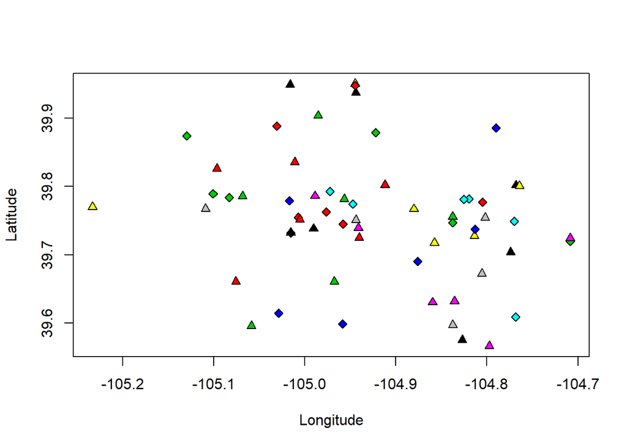

```r
par(mfrow=c(1,1))
plot(denver.model.A$locations$long,
     denver.model.A$locations$lat,
     pch=23+floor(I.col.A/max(I.col.A)+.5), bg=I.col.A,
     xlab="Longitude", ylab="Latitude")
```

```r
map("county", "colorado", col="#FFFF0055",fill=TRUE, add=TRUE)
```

ID starting conditions using previous model without CV:

```r
x.init.A.cv <- coef(est.denver.model.A, pars="cov")[,c("par","init")]
x.init.A.cv
```

|  | par | init |
| --- | --- | --- |
| log.nugget.const.iid | -6.460167 | -1 |
| log.nugget.V1.iid | -6.592943 | -1 |
| nu.log.range.exp | 15.000000 | 12 |
| nu.log.sill.exp | -2.943548 | -5 |
| nu.log.nugget.(Intercept).exp | -5.577657 | -1 |

Run the model with cross validation

```r
est.denver.A.cv <- estimateCV(denver.model.A, x.init.A.cv, Ind.cv.A)
```

```
## Estimation of CV-set 1/10
```

```
## Optimisation using starting value 1/2
```

```
## N = 5, M = 5 machine precision = 2.22045e-16
## At X0, 1 variables are exactly at the bounds
## At iterate     0  f=      -1269.5  |proj g|=       1.1045
##
## iterations 9
## function evaluations 21
## segments explored during Cauchy searches 9
## BFGS updates skipped 0
## active bounds at final generalized Cauchy point 1
## norm of the final projected gradient 0.0088038
## final function value -1269.54
##
## F = -1269.54
```

```
## Optimisation using starting value 2/2
```

```
## N = 5, M = 5 machine precision = 2.22045e-16
## At X0, 0 variables are exactly at the bounds
## At iterate     0  f=      -216.25  |proj g|=           14
## At iterate    10  f =      -1265.2  |proj g|=        12.187
##
## iterations 19
## function evaluations 31
## segments explored during Cauchy searches 22
## BFGS updates skipped 0
## active bounds at final generalized Cauchy point 1
## norm of the final projected gradient 0.00414808
## final function value -1269.54
##
## F = -1269.54
```

```
## Estimation of CV-set 2/10
```

```
## Optimisation using starting value 1/2
```

```
## N = 5, M = 5 machine precision = 2.22045e-16
## At X0, 1 variables are exactly at the bounds
## At iterate     0  f=      -1294.3  |proj g|=       11.916
##
## iterations 9
## function evaluations 21
## segments explored during Cauchy searches 9
## BFGS updates skipped 0
## active bounds at final generalized Cauchy point 1
## norm of the final projected gradient 0.0426284
## final function value -1294.72
##
## F = -1294.72
```

```
## Optimisation using starting value 2/2
```

```
## N = 5, M = 5 machine precision = 2.22045e-16
## At X0, 0 variables are exactly at the bounds
## At iterate     0  f=      -222.72  |proj g|=           14
## At iterate    10  f =        -1290  |proj g|=        12.207
##
## iterations 18
## function evaluations 38
## segments explored during Cauchy searches 21
## BFGS updates skipped 0
## active bounds at final generalized Cauchy point 1
## norm of the final projected gradient 0.00782871
## final function value -1294.72
##
## F = -1294.72
## l(0) > u(0).  No feasible solutionfinal  value -1294.722104
```

```
## Estimation of CV-set 3/10
```

```
## Optimisation using starting value 1/2
```

```
## N = 5, M = 5 machine precision = 2.22045e-16
## At X0, 1 variables are exactly at the bounds
## At iterate     0  f=        -1286  |proj g|=       10.358
##
## iterations 8
## function evaluations 11
## segments explored during Cauchy searches 8
## BFGS updates skipped 0
## active bounds at final generalized Cauchy point 1
## norm of the final projected gradient 0.0203885
## final function value -1286.3
##
## F = -1286.3
```

```
## Optimisation using starting value 2/2
```

```
## N = 5, M = 5 machine precision = 2.22045e-16
## At X0, 0 variables are exactly at the bounds
## At iterate     0  f=      -221.14  |proj g|=           14
## At iterate    10  f =      -1280.7  |proj g|=        12.213
##
## iterations 18
## function evaluations 32
## segments explored during Cauchy searches 21
## BFGS updates skipped 0
## active bounds at final generalized Cauchy point 1
## norm of the final projected gradient 0.0126759
## final function value -1286.3
##
## F = -1286.3
```

```
## Estimation of CV-set 4/10
```

```
## Optimisation using starting value 1/2
```

```
## N = 5, M = 5 machine precision = 2.22045e-16
## At X0, 1 variables are exactly at the bounds
## At iterate     0  f=      -1279.8  |proj g|=       1.3685
## Bad direction in the line search;
##    refresh the lbfgs memory and restart the iteration.
## Line search cannot locate an adequate point after 20 function
## and gradient evaluations
```

```
## Optimisation using starting value 2/2
```

```
## N = 5, M = 5 machine precision = 2.22045e-16
## At X0, 0 variables are exactly at the bounds
## At iterate     0  f=      -218.47  |proj g|=           14
## At iterate    10  f =        -1277  |proj g|=        9.4598
##
## iterations 19
## function evaluations 35
## segments explored during Cauchy searches 22
## BFGS updates skipped 0
## active bounds at final generalized Cauchy point 1
## norm of the final projected gradient 0.026482
## final function value -1279.94
##
## F = -1279.94
## l(0) > u(0).  No feasible solutionfinal  value -1279.941952
```

```
## Estimation of CV-set 5/10
```

```
## Optimisation using starting value 1/2
```

```
## N = 5, M = 5 machine precision = 2.22045e-16
## At X0, 1 variables are exactly at the bounds
## At iterate     0  f=      -1298.8  |proj g|=       9.4223
## At iterate    10  f =      -1299.6  |proj g|=      0.007108
##
## iterations 12
## function evaluations 15
## segments explored during Cauchy searches 13
## BFGS updates skipped 0
## active bounds at final generalized Cauchy point 1
## norm of the final projected gradient 0.000398628
## final function value -1299.58
##
## F = -1299.58
```

```
## Optimisation using starting value 2/2
```

```
## N = 5, M = 5 machine precision = 2.22045e-16
## At X0, 0 variables are exactly at the bounds
## At iterate     0  f=      -217.84  |proj g|=           14
## At iterate    10  f =      -1297.6  |proj g|=        9.3895
##
## iterations 18
## function evaluations 30
## segments explored during Cauchy searches 21
## BFGS updates skipped 0
## active bounds at final generalized Cauchy point 1
## norm of the final projected gradient 0.0142995
## final function value -1299.58
##
## F = -1299.58
```

```
## Estimation of CV-set 6/10
```

```
## Optimisation using starting value 1/2
```

```
## N = 5, M = 5 machine precision = 2.22045e-16
## At X0, 1 variables are exactly at the bounds
## At iterate     0  f=      -1297.4  |proj g|=       12.245
## Bad direction in the line search;
##    refresh the lbfgs memory and restart the iteration.
##
## iterations 9
## function evaluations 43
## segments explored during Cauchy searches 10
## BFGS updates skipped 0
## active bounds at final generalized Cauchy point 1
## norm of the final projected gradient 0.0165841
## final function value -1297.9
##
## F = -1297.9
```

```
## Optimisation using starting value 2/2
```

```
## N = 5, M = 5 machine precision = 2.22045e-16
## At X0, 0 variables are exactly at the bounds
## At iterate     0  f=      -222.71  |proj g|=           14
## At iterate    10  f =      -1294.4  |proj g|=        9.5141
##
## iterations 18
## function evaluations 29
## segments explored during Cauchy searches 21
## BFGS updates skipped 0
## active bounds at final generalized Cauchy point 1
## norm of the final projected gradient 0.00166492
## final function value -1297.9
##
## F = -1297.9
```

```
## Estimation of CV-set 7/10
```

```
## Optimisation using starting value 1/2
```

```
## N = 5, M = 5 machine precision = 2.22045e-16
## At X0, 1 variables are exactly at the bounds
## At iterate     0  f=      -1280.9  |proj g|=        3.807
## At iterate    10  f =        -1281  |proj g|=      0.011974
##
## iterations 11
## function evaluations 22
## segments explored during Cauchy searches 11
## BFGS updates skipped 0
## active bounds at final generalized Cauchy point 1
## norm of the final projected gradient 0.0119745
## final function value -1280.98
##
## F = -1280.98
```

```
## Optimisation using starting value 2/2
```

```
## N = 5, M = 5 machine precision = 2.22045e-16
## At X0, 0 variables are exactly at the bounds
## At iterate     0  f=      -216.96  |proj g|=           14
## At iterate    10  f =      -1280.8  |proj g|=        3.7684
##
## iterations 17
## function evaluations 32
## segments explored during Cauchy searches 20
## BFGS updates skipped 0
## active bounds at final generalized Cauchy point 1
## norm of the final projected gradient 0.0352993
## final function value -1280.98
##
## F = -1280.98
## l(0) > u(0).  No feasible solutionfinal  value -1280.981468
```

```
## Estimation of CV-set 8/10
```

```
## Optimisation using starting value 1/2
```

```
## N = 5, M = 5 machine precision = 2.22045e-16
## At X0, 1 variables are exactly at the bounds
## At iterate     0  f=      -1284.9  |proj g|=       3.1695
## At iterate    10  f =      -1284.9  |proj g|=      0.018043
##
## iterations 11
## function evaluations 14
## segments explored during Cauchy searches 11
## BFGS updates skipped 0
## active bounds at final generalized Cauchy point 1
## norm of the final projected gradient 0.0112303
## final function value -1284.93
##
## F = -1284.93
```

```
## Optimisation using starting value 2/2
```

```
## N = 5, M = 5 machine precision = 2.22045e-16
## At X0, 0 variables are exactly at the bounds
## At iterate     0  f=      -219.43  |proj g|=           14
## At iterate    10  f =        -1283  |proj g|=        9.4462
##
## iterations 19
## function evaluations 24
## segments explored during Cauchy searches 22
## BFGS updates skipped 0
## active bounds at final generalized Cauchy point 1
## norm of the final projected gradient 0.0652639
## final function value -1284.93
##
## F = -1284.93
```

```
## Estimation of CV-set 9/10
```

```
## Optimisation using starting value 1/2
```

```
## N = 5, M = 5 machine precision = 2.22045e-16
## At X0, 1 variables are exactly at the bounds
## At iterate     0  f=      -1280.4  |proj g|=       10.165
##
## iterations 9
## function evaluations 22
## segments explored during Cauchy searches 9
## BFGS updates skipped 0
## active bounds at final generalized Cauchy point 1
## norm of the final projected gradient 0.0363898
## final function value -1280.83
##
## F = -1280.83
```

```
## Optimisation using starting value 2/2
```

```
## N = 5, M = 5 machine precision = 2.22045e-16
## At X0, 0 variables are exactly at the bounds
## At iterate     0  f=      -218.99  |proj g|=           14
## At iterate    10  f =      -1275.5  |proj g|=        12.204
##
## iterations 18
## function evaluations 29
## segments explored during Cauchy searches 21
## BFGS updates skipped 0
## active bounds at final generalized Cauchy point 1
## norm of the final projected gradient 0.00675876
## final function value -1280.83
##
## F = -1280.83
```

```
## Estimation of CV-set 10/10
```

```
## Optimisation using starting value 1/2
```

```
## N = 5, M = 5 machine precision = 2.22045e-16
## At X0, 1 variables are exactly at the bounds
## At iterate     0  f=      -1290.3  |proj g|=       7.9042
## At iterate    10  f =      -1291.7  |proj g|=      0.024543
## Bad direction in the line search;
##    refresh the lbfgs memory and restart the iteration.
##
## iterations 12
## function evaluations 45
## segments explored during Cauchy searches 13
## BFGS updates skipped 0
## active bounds at final generalized Cauchy point 1
## norm of the final projected gradient 0.0146305
## final function value -1291.72
##
## F = -1291.72
## l(0) > u(0).  No feasible solutionfinal  value -1291.721758
```

```
## Optimisation using starting value 2/2
```

```
## N = 5, M = 5 machine precision = 2.22045e-16
## At X0, 0 variables are exactly at the bounds
## At iterate     0  f=      -221.07  |proj g|=           14
## At iterate    10  f =      -1286.6  |proj g|=        11.862
## At iterate    20  f =      -1291.7  |proj g|=     0.0051892
##
## iterations 21
## function evaluations 25
## segments explored during Cauchy searches 24
## BFGS updates skipped 0
## active bounds at final generalized Cauchy point 1
## norm of the final projected gradient 0.00109605
## final function value -1291.72
##
## F = -1291.72
```

```r
print(est.denver.A.cv)
```

```
## Cross-validation parameter estimation for STmodel
##   with 10 CV-groups and 2 starting points.
##   Results: 10 converged, 0 not converged.
##
## No fixed parameters.
##
## Estimated function values and convergence info:
##       value convergence conv eigen.min eigen.all.min
## 1  1269.540        TRUE TRUE  2.574754            NA
## 2  1294.722        TRUE TRUE  2.837362            NA
## 3  1286.305        TRUE TRUE  2.836648            NA
## 4  1279.942        TRUE TRUE  2.849047            NA
## 5  1299.577        TRUE TRUE  2.936357            NA
## 6  1297.899        TRUE TRUE  2.407874            NA
## 7  1280.981        TRUE TRUE  2.952668            NA
## 8  1284.926        TRUE TRUE  2.332440            NA
## 9  1280.830        TRUE TRUE  2.843492            NA
## 10 1291.722        TRUE TRUE  2.779136            NA
```

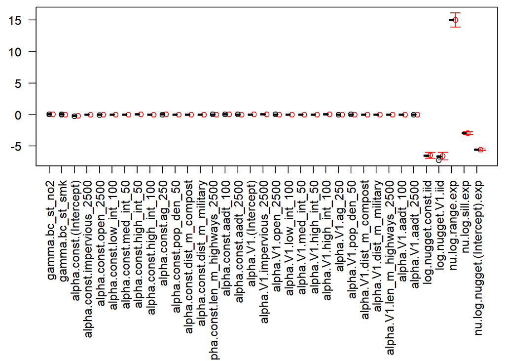

```r
par(mfrow=c(1,1), mar=c(13.5,2.5,.5,.5), las=2)
with(coef(est.denver.model.A, pars="all"),
     plotCI((1:length(par))+.3, par, uiw=1.96*sd,
             col=2, xlab="", xaxt="n", ylab=""))
boxplot(est.denver.A.cv, "all", boxwex=.4, col="grey", add=TRUE)
```

```r
#' Save the results as an .rdata object
save(denver.data.A, denver.model.A, est.denver.model.A, est.denver.A.cv,
     file = here::here("Results", "Denver_ST_Model_A.rdata"))
```

### 3.1.4 Prediction using the CV model

Making predictions using the CV model. Printing out the CV summary statistics as well

```r
pred.A.cv <- predictCV(denver.model.A, est.denver.A.cv, LTA = T)
pred.A.cv.log <- predictCV(denver.model.A, est.denver.A.cv,
                           LTA = T, transform="unbiased")

summary(pred.A.cv)
```

```
## Cross-validation predictions for STmodel with 10 CV-groups.
##   Predictions for 615 observations.
##   Temporal averages for 60 locations.
##
## RMSE:
##              EX.mu EX.mu.beta         EX
## obs     0.15802082 0.15802082 0.09433091
## average 0.09447449 0.09447449 0.06374833
##
## R2:
##             EX.mu EX.mu.beta        EX
## obs     0.4110067  0.4110067 0.7901109
## average 0.6121670  0.6121670 0.8234152
##
## Coverage of 95% prediction intervals:
##               EX
## obs     0.902439
## average 0.850000
```

```r
summary(pred.A.cv.log)
```

```
## Cross-validation predictions for STmodel with 10 CV-groups.
##   Predictions for 615 observations.
##   Temporal averages for 60 locations.
##
## RMSE:
##             EX.mu EX.mu.beta         EX    EX.pred
## obs     0.1851357  0.1851357 0.11135300 0.11139511
## average 0.1098840  0.1098840 0.07130562 0.07149704
##
## R2:
##             EX.mu EX.mu.beta        EX   EX.pred
## obs     0.4690742  0.4690742 0.8079309 0.8077856
## average 0.6771406  0.6771406 0.8640459 0.8633150
##
## Coverage of 95% prediction intervals:
##          EX.pred
## obs     0.902439
## average 0.850000
```

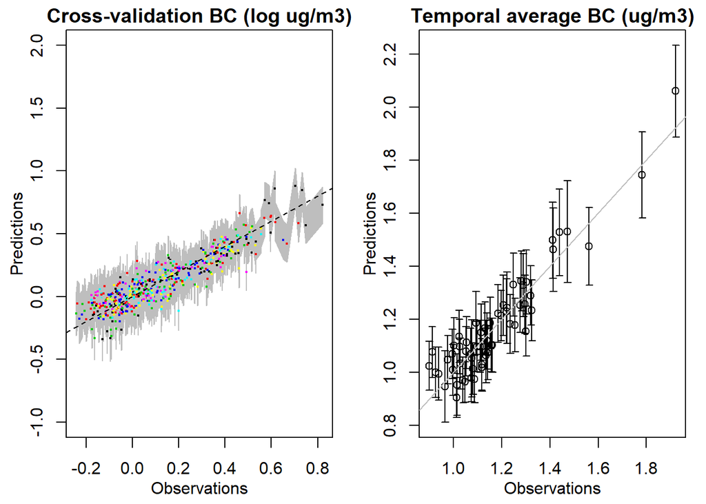

```r
par(mfrow=c(1,2), mar=c(3.3,3.3,1.5,1), mgp=c(2,1,0))
plot(pred.A.cv, "obs", ID="all", pch=c(19,NA), cex=.25, lty=c(NA,2),
     col=c("ID", "black", "grey"),
     ylim=c(-1,2),
     xlab="Observations", ylab="Predictions",
     main="Cross-validation BC (log ug/m3)")
with(pred.A.cv.log$pred.LTA, plotCI(obs, EX.pred, uiw=1.96*sqrt(VX.pred),
                                      xlab="Observations", ylab="Predictions",
                                      main="Temporal average BC (ug/m3)"))
abline(0, 1, col="grey")
```

```r
# jpeg(filename = here::here("Figs", "ST_CV_Obs_vs_Pred_BC_ModA.jpeg"),
#      width = 8, height = 4, units = "in", res = 500)
# par(mfrow=c(1,2), mar=c(3.3,3.3,1.5,1), mgp=c(2,1,0))
# plot(pred.A.cv, "obs", ID="all", pch=c(19,NA), cex=.25, lty=c(NA,2),
#      col=c("ID", "black", "grey"),
#      ylim=c(-1,2),
#      xlab="Observations", ylab="Predictions",
#      main="Cross-validation BC (log ug/m3)")
# with(pred.A.cv.log$pred.LTA, plotCI(obs, EX.pred, uiw=1.96*sqrt(VX.pred),
#                                       xlab="Observations", ylab="Predictions",
#                                       main="Temporal average BC (ug/m3)"))
# abline(0, 1, col="grey")
# dev.off()
```

### 3.1.5 Predictions for 2009-2019

What do the long-term predictions look like for this model? Predicting at the distributed (residential + community) sites

```r
x.A <- coef(est.denver.model.A, pars = "cov")$par
x.A
```

```
## [1] -6.460167 -6.592943 15.000000 -2.943548 -5.577657
```

```r
E.A <- predict(denver.model.A, est.denver.model.A, LTA = T,
               transform="unbiased", pred.var=FALSE)
print(E.A)
```

```
## Prediction for STmodel.
##
## Regression parameters:
##   0 Spatio-temporal covariate(s).
##   28 beta-fields regression parameters in x$pars.
##
## Regression parameters are assumed to be known and
##  prediction variances do NOT include
##  uncertainties in regression parameters.
##
## Prediction of beta-fields, (x$beta):
## List of 2
##  $ mu: num [1:61, 1:2] -0.197 -0.209 -0.141 -0.149 -0.181 ...
##   ..- attr(*, "dimnames")=List of 2
##  $ EX: num [1:61, 1:2] -0.193 -0.174 -0.148 -0.127 -0.243 ...
##   ..- attr(*, "dimnames")=List of 2
##
## Predictions for log-Gaussian field of type: unbiased
##
## Predictions for 521 times at 61 locations.
## List of 5
##  $ EX.mu     : num [1:521, 1:61] 1.09 1.06 1.25 1.12 1.15 ...
##   ..- attr(*, "dimnames")=List of 2
##  $ EX.mu.beta: num [1:521, 1:61] 1.14 1.1 1.29 1.15 1.18 ...
##   ..- attr(*, "dimnames")=List of 2
##  $ EX        : num [1:521, 1:61] 1.17 1.13 1.33 1.18 1.21 ...
##   ..- attr(*, "dimnames")=List of 2
##  $ EX.pred   : num [1:521, 1:61] 1.17 1.13 1.33 1.19 1.21 ...
##   ..- attr(*, "dimnames")=List of 2
##  $ log.EX    : num [1:521, 1:61] 0.1272 0.0933 0.2568 0.1414 0.164 ...
##   ..- attr(*, "dimnames")=List of 2
##
## Variances have been computed.
## List of 2
##  $ log.VX     : num [1:521, 1:61] 0.0555 0.055 0.0546 0.0542 0.0539 ...
##   ..- attr(*, "dimnames")=List of 2
##  $ log.VX.pred: num [1:521, 1:61] 0.0593 0.0588 0.0584 0.058 0.0577 ...
##   ..- attr(*, "dimnames")=List of 2
##
## Mean squared prediciton errors NOT been computed.
##
## 61 temporal averages have been compute.
## List of 1
##  $ LTA:'data.frame': 61 obs. of  4 variables:
```

```r
week_preds <- as.data.frame(E.A$EX) %>%
  mutate(week = as.Date(rownames(E.A$EX)),
         year = year(as.Date(rownames(E.A$EX))))

week_sites <- colnames(week_preds)[which(str_detect(colnames(week_preds), "d_"))]

box_preds <- week_preds %>%
  select(week, all_of(week_sites)) %>%
  #filter(week %in% week_weeks) %>%
  mutate(month = month(week),
         year = year(week)) %>%
  filter(year %in% c(2009:2019))

box_data <- box_preds %>%
  pivot_longer(-c(week, month, year), names_to = "location", values_to = "pred")
summary(box_data)
```

```
##       week                month            year        location
##  Min.   :2009-01-05   Min.   : 1.00   Min.   :2009   Length:31200
##  1st Qu.:2011-07-16   1st Qu.: 4.00   1st Qu.:2011   Class :character
##  Median :2014-01-09   Median : 7.00   Median :2014   Mode  :character
##  Mean   :2014-01-08   Mean   : 6.51   Mean   :2014
##  3rd Qu.:2016-07-05   3rd Qu.: 9.25   3rd Qu.:2016
##  Max.   :2018-12-31   Max.   :12.00   Max.   :2018
##
##       pred
##  Min.   :0.5085
##  1st Qu.:1.1206
##  Median :1.2595
##  Mean   :1.3012
##  3rd Qu.:1.4468
##  Max.   :3.7650
##  NA's   :480
```

```r
#' Box plot of weekly BC predicted at all distributed sites grouped by month
box_summary <- box_data %>%
  group_by(month) %>%
  summarize(median = median(pred, na.rm=T)) %>%
  arrange(desc(median))
box_summary
```

| month | median |
| --- | --- |
| 12 | 1.537380 |
| 1 | 1.450785 |
| 11 | 1.435169 |
| 2 | 1.395557 |
| 10 | 1.317630 |
| 3 | 1.237553 |
| 9 | 1.235691 |
| 8 | 1.224569 |
| 7 | 1.161995 |
| 6 | 1.137076 |

[output cut: 2 more lines]

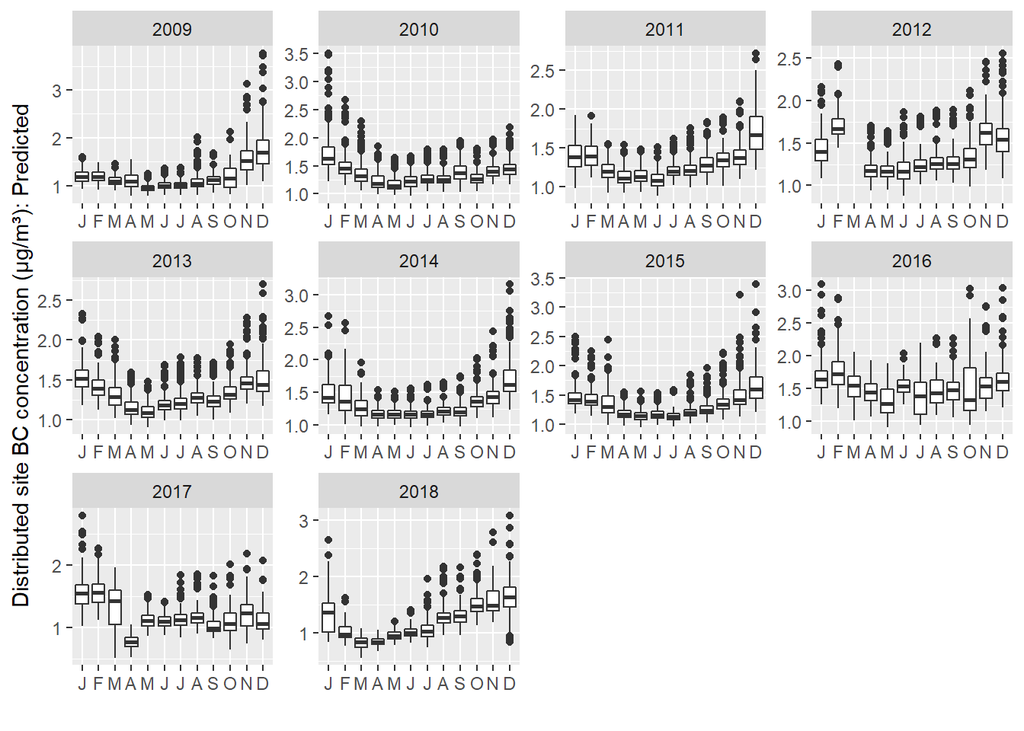

```r
pred_box_plot <- ggplot(box_data) +
  geom_boxplot(aes(x = as.factor(month), y = pred), #, color = as.factor(month)),
               show.legend = F) +
  #scale_color_viridis(name = "Month", discrete = T) +
  facet_wrap(. ~ year, scales = "free") +
  xlab("") + ylab("Distributed site BC concentration (\u03BCg/m\u00B3): Predicted") +
  # theme(axis.text.x = element_text(angle = 45, vjust = 1, hjust = 1)) +
  scale_x_discrete(labels = str_sub(month.name, 1, 1))
pred_box_plot
```

## 3.2 Model B: 2 temporal trend (basis) functions

### 3.2.1 Create the model object

For this version of the model, use `iid` for `cov.beta` (beta, beta1, beta2) and `exp` for `cov.nu` (error). Here we can specify different LUR formluae. The length of the LUR list should be number of basis functions + 1.

```r
denver.data.B <- denver.data2.2
names(denver.data.B$covars)
```

```
##  [1] "ID"                  "lon"                 "lat"
##  [4] "impervious_2500"     "open_2500"           "low_int_100"
##  [7] "med_int_50"          "high_int_50"         "high_int_100"
## [10] "ag_250"              "pop_den_50"          "dist_m_compost"
## [13] "dist_m_military"     "len_m_highways_2500" "aadt_100"
## [16] "aadt_2500"           "x"                   "y"
## [19] "type"
```

```r
LUR.B <- list(covar_fun, covar_fun, covar_fun)

cov.beta.B <-  list(covf = c("iid", "iid", "iid"), nugget = T)
cov.nu.B <- list(covf = "exp", nugget = T, random.effect = FALSE)
locations.B <- list(coords = c("x","y"), long.lat = c("lon","lat"), others= "type")

denver.model.B <- createSTmodel(denver.data.B, LUR = LUR.B,
                                ST = c("bc_st_no2", "bc_st_smk"),
                                cov.beta = cov.beta.B, cov.nu = cov.nu.B,
                                locations = locations.B)
```

```
## No trend $trend.fnc object detected, STdata probably from old version of the package.
## $trend.fnc has been added based on spline fit to elements in STmodel$trend.
```

```r
denver.model.B
```

```
## STmodel-object with:
##  No. locations: 61 (observed: 61)
##  No. time points: 521 (observed: 148)
##  No. obs: 763
##
## Trend with 2 basis function(s):
## [1] "V1" "V2"
## with dates:
##  2008-12-29 to 2018-12-31
##
## Models for the beta-fields are:
## $const
## ~~impervious_2500 + open_2500 + low_int_100 + med_int_50 + high_int_50 +
##     high_int_100 + ag_250 + pop_den_50 + dist_m_compost + dist_m_military +
##     len_m_highways_2500 + aadt_100 + aadt_2500
##
## $V1
## ~~impervious_2500 + open_2500 + low_int_100 + med_int_50 + high_int_50 +
##     high_int_100 + ag_250 + pop_den_50 + dist_m_compost + dist_m_military +
##     len_m_highways_2500 + aadt_100 + aadt_2500
##
## $V2
## ~~impervious_2500 + open_2500 + low_int_100 + med_int_50 + high_int_50 +
##     high_int_100 + ag_250 + pop_den_50 + dist_m_compost + dist_m_military +
##     len_m_highways_2500 + aadt_100 + aadt_2500
##
## 2 spatio-temporal covariate(s):
## [1] "bc_st_no2" "bc_st_smk"
##
## Covariance model for the beta-field(s):
##  Covariance type(s): iid, iid, iid
##  Nugget: Yes, Yes, Yes
## Covariance model for the nu-field(s):
##  Covariance type: exp
##  Nugget: ~1
##  Random effect: No
## All sites:
## central    dist
##       1      60
## Observed:
## central    dist
##       1      60
##
## For central:
##   Number of obs: 148
##   Dates: 2016-02-08 to 2018-12-31
## For dist:
##   Number of obs: 615
##   Dates: 2018-05-07 to 2018-11-12
```

### 3.2.2 Estimate model parameters

- nugget values can range from -1 to -6
- range values can range from 0 to 4
- try starting values where the sill and nugget are the same (e.g., both 0) and where they are very different (e.g., 0 and -5)
- make sure the starting values are pretty different

```r
names <- loglikeSTnames(denver.model.B, all=FALSE)
names
```

```
## [1] "log.nugget.const.iid"          "log.nugget.V1.iid"
## [3] "log.nugget.V2.iid"             "nu.log.range.exp"
## [5] "nu.log.sill.exp"               "nu.log.nugget.(Intercept).exp"
```

```r
# x.init.B <- cbind(c(0, 0, 0, 0, 0, 0),
#                   c(-1, -1, -1, 0, -1, -1),
#                   c(-1, -1, -1, 0, -5, -1),
#                   c(-5, -5, -5, 0, -1, -5),
#                   c(-5, -5, -5, 0, -5, -5),
#                   c(-1, -1, -1, 2, -1, -1),
#                   c(-1, -1, -1, 2, -5, -1),
#                   c(-5, -5, -5, 2, -1, -5),
#                   c(-5, -5, -5, 2, -5, -5),
#                   c(-1, -1, -1, 4, -1, -1),
#                   c(-1, -1, -1, 4, -5, -1),
#                   c(-5, -5, -5, 4, -1, -5),
#                   c(-5, -5, -5, 4, -5, -5))

x.init.B <- cbind(c(0, 0, 0, 0, 0, 0),
                  c(-10, -5, -5, 4, -3, -5),
                  c(-10, -5, -5, 4, -5, -5),
                  c(-10, -5, -5, 6, -3, -5),
                  c(-10, -5, -5, 6, -5, -5),
                  c(-10, -5, -5, 8, -3, -5),
                  c(-10, -5, -5, 8, -5, -5),
                  c(-10, -5, -5, 10, -3, -5),
                  c(-10, -5, -5, 10, -5, -5))

rownames(x.init.B) <- loglikeSTnames(denver.model.B, all=FALSE)
x.init.B
```

```
##                               [,1] [,2] [,3] [,4] [,5] [,6] [,7] [,8] [,9]
## log.nugget.const.iid             0  -10  -10  -10  -10  -10  -10  -10  -10
## log.nugget.V1.iid                0   -5   -5   -5   -5   -5   -5   -5   -5
## log.nugget.V2.iid                0   -5   -5   -5   -5   -5   -5   -5   -5
## nu.log.range.exp                 0    4    4    6    6    8    8   10   10
## nu.log.sill.exp                  0   -3   -5   -3   -5   -3   -5   -3   -5
## nu.log.nugget.(Intercept).exp    0   -5   -5   -5   -5   -5   -5   -5   -5
```

```r
#' Difference from tutorial: use Josh Keller's version of the function
source(here::here("Code", "functions_model.R"))
est.denver.model.B <- estimate.STmodel(denver.model.B, x.init.B)
```

```
## Optimisation using starting value 1/9
```

```
## N = 6, M = 5 machine precision = 2.22045e-16
## At X0, 0 variables are exactly at the bounds
## At iterate     0  f=       401.78  |proj g|=           15
## At iterate    10  f =      -1162.4  |proj g|=       0.55988
## At iterate    20  f =        -1163  |proj g|=      0.046916
##
## iterations 22
## function evaluations 35
## segments explored during Cauchy searches 26
## BFGS updates skipped 0
## active bounds at final generalized Cauchy point 0
## norm of the final projected gradient 0.0611269
## final function value -1162.95
##
## F = -1162.95
```

```
## Optimisation using starting value 2/9
```

```
## N = 6, M = 5 machine precision = 2.22045e-16
## At X0, 0 variables are exactly at the bounds
## At iterate     0  f=      -929.64  |proj g|=           12
## At iterate    10  f =        -1162  |proj g|=          3.07
## At iterate    20  f =      -1162.8  |proj g|=       0.15317
## At iterate    30  f =      -1162.9  |proj g|=       0.90124
## At iterate    40  f =      -1364.7  |proj g|=        20.835
## ys=-2.594e+00  -gs= 2.719e-01, BFGS update SKIPPED
## At iterate    50  f =      -1404.5  |proj g|=       0.18298
## At iterate    60  f =        -1452  |proj g|=       0.10568
## ys=-1.388e+00  -gs= 2.676e-01, BFGS update SKIPPED
## At iterate    70  f =      -1484.8  |proj g|=         3.125
##
## iterations 76
## function evaluations 102
## segments explored during Cauchy searches 79
## BFGS updates skipped 2
## active bounds at final generalized Cauchy point 1
## norm of the final projected gradient 0.00658018
## final function value -1485.09
##
## F = -1485.09
```

```
## Optimisation using starting value 3/9
```

```
## N = 6, M = 5 machine precision = 2.22045e-16
## At X0, 0 variables are exactly at the bounds
## At iterate     0  f=      -1090.5  |proj g|=           20
## At iterate    10  f =      -1162.6  |proj g|=       0.47656
## At iterate    20  f =      -1162.8  |proj g|=        0.3365
## ys=-8.496e-04  -gs= 5.963e-03, BFGS update SKIPPED
## At iterate    30  f =        -1163  |proj g|=      0.070208
## ys=-1.406e+02  -gs= 3.882e-01, BFGS update SKIPPED
## At iterate    40  f =      -1381.7  |proj g|=        6.8904
## At iterate    50  f =      -1404.5  |proj g|=        1.0257
##
## iterations 59
## function evaluations 84
## segments explored during Cauchy searches 64
## BFGS updates skipped 2
## active bounds at final generalized Cauchy point 1
## norm of the final projected gradient 0.0501614
## final function value -1451.99
##
## F = -1451.99
```

```
## Optimisation using starting value 4/9
```

```
## N = 6, M = 5 machine precision = 2.22045e-16
## At X0, 0 variables are exactly at the bounds
## At iterate     0  f=       -931.8  |proj g|=           12
## At iterate    10  f =      -1346.2  |proj g|=         19.06
## At iterate    20  f =      -1424.1  |proj g|=         20.56
## At iterate    30  f =      -1469.7  |proj g|=           9.4
##
## iterations 38
## function evaluations 56
## segments explored during Cauchy searches 41
## BFGS updates skipped 0
## active bounds at final generalized Cauchy point 1
## norm of the final projected gradient 0.0123519
## final function value -1478.05
##
## F = -1478.05
## l(0) > u(0).  No feasible solutionfinal  value -1478.048983
```

```
## Optimisation using starting value 5/9
```

```
## N = 6, M = 5 machine precision = 2.22045e-16
## At X0, 0 variables are exactly at the bounds
## At iterate     0  f=      -1092.1  |proj g|=           20
## At iterate    10  f =      -1408.4  |proj g|=        3.5747
## At iterate    20  f =      -1470.6  |proj g|=        18.493
## At iterate    30  f =      -1478.2  |proj g|=       0.13435
## At iterate    40  f =      -1479.8  |proj g|=        6.5287
## At iterate    50  f =        -1485  |proj g|=       0.58897
## At iterate    60  f =      -1485.1  |proj g|=      0.039705
##
## iterations 61
## function evaluations 98
## segments explored during Cauchy searches 65
## BFGS updates skipped 0
## active bounds at final generalized Cauchy point 2
## norm of the final projected gradient 0.0397053
## final function value -1485.09
##
## F = -1485.09
```

```
## Optimisation using starting value 6/9
```

```
## N = 6, M = 5 machine precision = 2.22045e-16
## At X0, 0 variables are exactly at the bounds
## At iterate     0  f=      -974.27  |proj g|=           12
## At iterate    10  f =      -1484.8  |proj g|=       0.40006
## At iterate    20  f =      -1485.1  |proj g|=       0.23369
## At iterate    30  f =      -1485.1  |proj g|=     0.0051123
##
## iterations 30
## function evaluations 41
## segments explored during Cauchy searches 34
## BFGS updates skipped 0
## active bounds at final generalized Cauchy point 2
## norm of the final projected gradient 0.00511226
## final function value -1485.09
##
## F = -1485.09
```

```
## Optimisation using starting value 7/9
```

```
## N = 6, M = 5 machine precision = 2.22045e-16
## At X0, 0 variables are exactly at the bounds
## At iterate     0  f=      -1115.4  |proj g|=           20
## At iterate    10  f =      -1484.8  |proj g|=       0.43206
## At iterate    20  f =        -1485  |proj g|=        1.7983
## At iterate    30  f =      -1485.1  |proj g|=     0.0096948
##
## iterations 31
## function evaluations 45
## segments explored during Cauchy searches 36
## BFGS updates skipped 0
## active bounds at final generalized Cauchy point 2
## norm of the final projected gradient 0.00969469
## final function value -1485.09
##
## F = -1485.09
```

```
## Optimisation using starting value 8/9
```

```
## N = 6, M = 5 machine precision = 2.22045e-16
## At X0, 0 variables are exactly at the bounds
## At iterate     0  f=        -1153  |proj g|=           12
## At iterate    10  f =      -1484.8  |proj g|=       0.31126
## At iterate    20  f =      -1485.1  |proj g|=        1.2933
## At iterate    30  f =      -1485.1  |proj g|=     0.0073136
##
## iterations 30
## function evaluations 43
## segments explored during Cauchy searches 35
## BFGS updates skipped 0
## active bounds at final generalized Cauchy point 2
## norm of the final projected gradient 0.0073136
## final function value -1485.09
##
## F = -1485.09
```

```
## Optimisation using starting value 9/9
```

```
## N = 6, M = 5 machine precision = 2.22045e-16
## At X0, 0 variables are exactly at the bounds
## At iterate     0  f=      -1184.6  |proj g|=           20
## At iterate    10  f =      -1484.8  |proj g|=       0.59705
## At iterate    20  f =      -1485.1  |proj g|=        0.1945
## Bad direction in the line search;
##    refresh the lbfgs memory and restart the iteration.
## Line search cannot locate an adequate point after 20 function
## and gradient evaluations
```

```r
print(est.denver.model.B)
```

```
## Optimisation for STmodel with 9 starting points.
##   Results: 5 converged, 4 not converged, 0 failed.
##   Best result for starting point 5, optimisation has converged
##
## No fixed parameters.
##
## Estimated parameters for all starting point(s):
##                                           [,1]           [,2]           [,3]
## gamma.bc_st_no2                   0.0084996745   0.0115365606   0.0105398983
## gamma.bc_st_smk                   0.0924635530   0.0813038901   0.0832554386
## alpha.const.(Intercept)           0.1821040659   0.1029356335   0.1232651449
## alpha.const.impervious_2500       0.0560974757   0.0676463464   0.0678921726
## alpha.const.open_2500             0.0233014191   0.0299115541   0.0305957677
## alpha.const.low_int_100           0.0139781516   0.0218616849   0.0197240718
## alpha.const.med_int_50           -0.0021565653  -0.0062326947  -0.0030934554
## alpha.const.high_int_50           0.0092137688   0.0068177023   0.0047081658
## alpha.const.high_int_100         -0.0004742770  -0.0009993208   0.0009918762
## alpha.const.ag_250               -0.0026644277  -0.0028270351  -0.0023838195
## alpha.const.pop_den_50            0.0014505053  -0.0010965684  -0.0022273033
## alpha.const.dist_m_compost        0.0031388854  -0.0015027337  -0.0005862093
## alpha.const.dist_m_military       0.0177415643   0.0037320093   0.0054361195
## alpha.const.len_m_highways_2500   0.0017402105   0.0045488095   0.0067564516
## alpha.const.aadt_100              0.0224748694   0.0259453913   0.0245804139
## alpha.const.aadt_2500            -0.0008337298  -0.0113356312  -0.0117689467
## alpha.V1.(Intercept)              0.1409886041   0.0173813362   0.0291201796
## alpha.V1.impervious_2500          0.0158193840   0.0322814297   0.0213663377
## alpha.V1.open_2500                0.0146548190   0.0219862027   0.0124869287
## alpha.V1.low_int_100              0.0031083880   0.0039965957   0.0063711733
## alpha.V1.med_int_50              -0.0025593998   0.0067783597   0.0002978770
## alpha.V1.high_int_50             -0.0237437808   0.0012269203  -0.0018056842
## alpha.V1.high_int_100             0.0625014647   0.0161115276   0.0254379529
## alpha.V1.ag_250                   0.0185076063   0.0020116126   0.0019335083
## alpha.V1.pop_den_50               0.0168695201   0.0017316949   0.0021051153
## alpha.V1.dist_m_compost           0.0182002044   0.0040904305  -0.0010506950
## alpha.V1.dist_m_military          0.0093133022  -0.0038506604  -0.0088795033
## alpha.V1.len_m_highways_2500     -0.0018067808  -0.0103757615  -0.0092785711
## alpha.V1.aadt_100                -0.0431050115  -0.0043100047  -0.0075111441
## alpha.V1.aadt_2500               -0.0026057723  -0.0050505724  -0.0057401105
## alpha.V2.(Intercept)              0.1354334364   0.1368179747   0.1390315915
## alpha.V2.impervious_2500          0.0286962355   0.0296904444   0.0306547237
```

[output cut: 109 more lines]

```
## alpha.V2.dist_m_compost           0.015079155   0.015079388   0.015078405
## alpha.V2.dist_m_military          0.007161074   0.007160975   0.007160979
## alpha.V2.len_m_highways_2500      0.003928232   0.003928277   0.003928228
## alpha.V2.aadt_100                -0.020828619  -0.020828432  -0.020828610
## alpha.V2.aadt_2500               -0.009155678  -0.009155703  -0.009155980
## log.nugget.const.iid            -15.000000000 -15.000000000 -15.000000000
## log.nugget.V1.iid                -6.432538926  -6.432526499  -6.433154100
## log.nugget.V2.iid                -7.655895810  -7.656194716  -7.655483049
## nu.log.range.exp                 15.000000000  15.000000000  15.000000000
## nu.log.sill.exp                  -2.943856277  -2.943890326  -2.943783240
## nu.log.nugget.(Intercept).exp    -5.822240832  -5.822220883  -5.822170305
##
## Function value(s):
## [1] 1162.953 1485.088 1451.992 1478.049 1485.092 1485.092 1485.092 1485.092
## [9] 1485.092
```

### 3.2.3 Cross-validation

Define the CV groups

```r
set.seed(123)

unique(colnames(bc_obs2))
```

```
##  [1] "d_1"     "d_2"     "d_3"     "d_4"     "d_5"     "d_6"     "d_7"
##  [8] "d_8"     "d_9"     "d_10"    "d_11"    "d_12"    "d_13"    "d_14"
## [15] "d_15"    "d_16"    "d_17"    "d_18"    "d_19"    "d_20"    "d_21"
## [22] "d_22"    "d_23"    "d_24"    "d_25"    "d_26"    "d_27"    "d_28"
## [29] "d_29"    "d_30"    "d_31"    "d_32"    "d_33"    "d_34"    "d_35"
## [36] "d_36"    "d_37"    "d_38"    "d_39"    "d_40"    "d_41"    "d_42"
## [43] "d_43"    "d_44"    "d_45"    "d_46"    "d_47"    "d_48"    "d_49"
## [50] "d_50"    "d_51"    "d_52"    "d_53"    "d_54"    "d_55"    "d_56"
## [57] "d_57"    "d_58"    "d_59"    "d_60"    "central"
```

```r
Ind.cv.B <- createCV(denver.model.B, groups = 10, #min.dist = .1,
                     subset = paste0("d_", c(1:60)))

ID.cv.B <- sapply(split(denver.model.B$obs$ID, Ind.cv.B), unique)
print(sapply(ID.cv.B, length))
```

```
##  0  1  2  3  4  5  6  7  8  9 10
##  1  6  6  6  6  6  6  6  6  6  6
```

```r
table(Ind.cv.B)
```

```
## Ind.cv.B
##   0   1   2   3   4   5   6   7   8   9  10
## 148  71  53  58  67  66  52  66  61  61  60
```

```r
I.col.B <- apply(sapply(ID.cv.B, function(x) denver.model.B$locations$ID%in% x), 1,
                       function(x) if(sum(x)==1) which(x) else 0)
names(I.col.B) <- denver.model.B$locations$ID
print(I.col.B)
```

```
##     d_1     d_2     d_3     d_4     d_5     d_6     d_7     d_8     d_9    d_10
##       6       9      11       4      11       2       8      11       9       7
##    d_11    d_12    d_13    d_14    d_15    d_16    d_17    d_18    d_19    d_20
##       2       9      10       2      10      11       6      11       6      10
##    d_21    d_22    d_23    d_24    d_25    d_26    d_27    d_28    d_29    d_30
##       3       3       8       8       3       5      10       5       4       5
##    d_31    d_32    d_33    d_34    d_35    d_36    d_37    d_38    d_39    d_40
##       4       7       2       7       8       6       2       5       5       4
##    d_41    d_42    d_43    d_44    d_45    d_46    d_47    d_48    d_49    d_50
##       7       5       9       4       3       6       8      11       4       9
##    d_51    d_52    d_53    d_54    d_55    d_56    d_57    d_58    d_59    d_60
##       9       8      10       2       6       3       3       7       7      10
## central
##       1
```

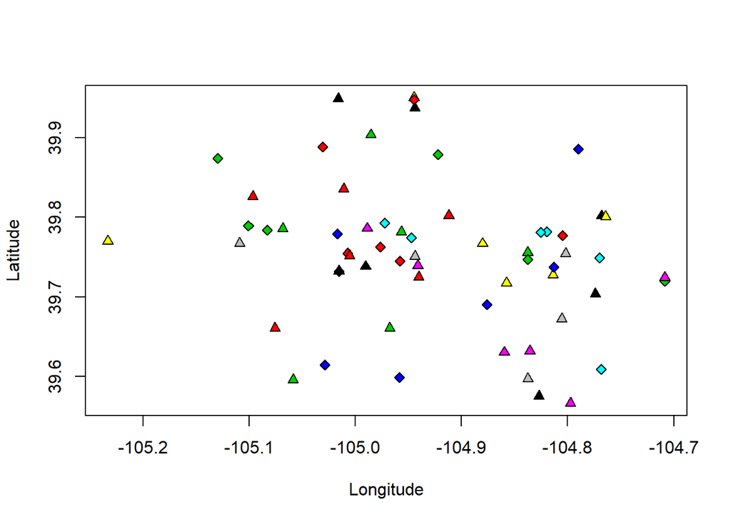

```r
par(mfrow=c(1,1))
plot(denver.model.B$locations$long,
     denver.model.B$locations$lat,
     pch=23+floor(I.col.B/max(I.col.B)+.5), bg=I.col.B,
     xlab="Longitude", ylab="Latitude")
```

```r
map("county", "colorado", col="#FFFF0055",fill=TRUE, add=TRUE)
```

ID starting conditions using previous model without CV:

```r
x.init.B.cv <- coef(est.denver.model.B, pars="cov")[,c("par","init")]
x.init.B.cv
```

|  | par | init |
| --- | --- | --- |
| log.nugget.const.iid | -15.000000 | -10 |
| log.nugget.V1.iid | -6.433437 | -5 |
| log.nugget.V2.iid | -7.656144 | -5 |
| nu.log.range.exp | 15.000000 | 6 |
| nu.log.sill.exp | -2.943827 | -5 |
| nu.log.nugget.(Intercept).exp | -5.822055 | -5 |

Run the model with cross validation

```r
est.denver.B.cv <- estimateCV(denver.model.B, x.init.B.cv, Ind.cv.B)
```

```
## Estimation of CV-set 1/10
```

```
## Optimisation using starting value 1/2
```

```
## N = 6, M = 5 machine precision = 2.22045e-16
## At X0, 2 variables are exactly at the bounds
## At iterate     0  f=      -1330.7  |proj g|=       3.5155
##
## iterations 8
## function evaluations 10
## segments explored during Cauchy searches 8
## BFGS updates skipped 0
## active bounds at final generalized Cauchy point 2
## norm of the final projected gradient 0.0092458
## final function value -1330.83
##
## F = -1330.83
```

```
## Optimisation using starting value 2/2
```

```
## N = 6, M = 5 machine precision = 2.22045e-16
## At X0, 0 variables are exactly at the bounds
## At iterate     0  f=      -963.42  |proj g|=           20
## ys=-1.874e+02  -gs= 1.747e+01, BFGS update SKIPPED
## At iterate    10  f =      -1224.3  |proj g|=        4.3008
## At iterate    20  f =      -1292.6  |proj g|=        9.6348
## At iterate    30  f =        -1324  |proj g|=        6.4996
## Bad direction in the line search;
##    refresh the lbfgs memory and restart the iteration.
##
## iterations 36
## function evaluations 82
## segments explored during Cauchy searches 41
## BFGS updates skipped 1
## active bounds at final generalized Cauchy point 1
## norm of the final projected gradient 0.00299473
## final function value -1326.29
##
## F = -1326.29
## l(0) > u(0).  No feasible solutionfinal  value -1326.290394
```

```
## Estimation of CV-set 2/10
```

```
## Optimisation using starting value 1/2
```

```
## N = 6, M = 5 machine precision = 2.22045e-16
## At X0, 2 variables are exactly at the bounds
## At iterate     0  f=      -1359.4  |proj g|=       7.8777
##
## iterations 9
## function evaluations 12
## segments explored during Cauchy searches 9
## BFGS updates skipped 0
## active bounds at final generalized Cauchy point 2
## norm of the final projected gradient 0.0175422
## final function value -1359.59
##
## F = -1359.59
```

```
## Optimisation using starting value 2/2
```

```
## N = 6, M = 5 machine precision = 2.22045e-16
## At X0, 0 variables are exactly at the bounds
## At iterate     0  f=      -996.65  |proj g|=           20
## ys=-3.021e+01  -gs= 2.205e+01, BFGS update SKIPPED
## At iterate    10  f =      -1230.6  |proj g|=        11.716
## At iterate    20  f =      -1305.5  |proj g|=        18.628
## At iterate    30  f =      -1346.9  |proj g|=        18.189
##
## iterations 38
## function evaluations 56
## segments explored during Cauchy searches 42
## BFGS updates skipped 1
## active bounds at final generalized Cauchy point 1
## norm of the final projected gradient 0.00757052
## final function value -1351.54
##
## F = -1351.54
```

```
## Estimation of CV-set 3/10
```

```
## Optimisation using starting value 1/2
```

```
## N = 6, M = 5 machine precision = 2.22045e-16
## At X0, 2 variables are exactly at the bounds
## At iterate     0  f=        -1345  |proj g|=       9.9226
##
## iterations 7
## function evaluations 10
## segments explored during Cauchy searches 7
## BFGS updates skipped 0
## active bounds at final generalized Cauchy point 2
## norm of the final projected gradient 0.0164109
## final function value -1345.25
##
## F = -1345.25
```

```
## Optimisation using starting value 2/2
```

```
## N = 6, M = 5 machine precision = 2.22045e-16
## At X0, 0 variables are exactly at the bounds
## At iterate     0  f=      -988.16  |proj g|=           20
## ys=-4.784e+01  -gs= 2.316e+01, BFGS update SKIPPED
## At iterate    10  f =      -1219.7  |proj g|=        10.838
## At iterate    20  f =        -1314  |proj g|=       0.96001
## At iterate    30  f =      -1339.1  |proj g|=      0.050443
##
## iterations 34
## function evaluations 51
## segments explored during Cauchy searches 38
## BFGS updates skipped 1
## active bounds at final generalized Cauchy point 1
## norm of the final projected gradient 0.00294752
## final function value -1339.15
##
## F = -1339.15
```

```
## Estimation of CV-set 4/10
```

```
## Optimisation using starting value 1/2
```

```
## N = 6, M = 5 machine precision = 2.22045e-16
## At X0, 2 variables are exactly at the bounds
## At iterate     0  f=      -1345.4  |proj g|=       5.9653
##
## iterations 9
## function evaluations 13
## segments explored during Cauchy searches 9
## BFGS updates skipped 0
## active bounds at final generalized Cauchy point 2
## norm of the final projected gradient 0.0114334
## final function value -1345.62
##
## F = -1345.62
```

```
## Optimisation using starting value 2/2
```

```
## N = 6, M = 5 machine precision = 2.22045e-16
## At X0, 0 variables are exactly at the bounds
## At iterate     0  f=      -973.63  |proj g|=           20
## ys=-2.121e+01  -gs= 1.138e+01, BFGS update SKIPPED
## At iterate    10  f =      -1128.8  |proj g|=        19.244
## At iterate    20  f =      -1297.8  |proj g|=        20.786
## At iterate    30  f =      -1336.8  |proj g|=        9.2937
##
## iterations 35
## function evaluations 57
## segments explored during Cauchy searches 39
## BFGS updates skipped 1
## active bounds at final generalized Cauchy point 1
## norm of the final projected gradient 0.00707711
## final function value -1339.58
##
## F = -1339.58
```

```
## Estimation of CV-set 5/10
```

```
## Optimisation using starting value 1/2
```

```
## N = 6, M = 5 machine precision = 2.22045e-16
## At X0, 2 variables are exactly at the bounds
## At iterate     0  f=      -1351.2  |proj g|=       8.2195
##
## iterations 8
## function evaluations 22
## segments explored during Cauchy searches 8
## BFGS updates skipped 0
## active bounds at final generalized Cauchy point 2
## norm of the final projected gradient 0.0251266
## final function value -1351.83
##
## F = -1351.83
## l(0) > u(0).  No feasible solutionfinal  value -1351.834977
```

```
## Optimisation using starting value 2/2
```

```
## N = 6, M = 5 machine precision = 2.22045e-16
## At X0, 0 variables are exactly at the bounds
## At iterate     0  f=      -976.04  |proj g|=           20
## ys=-1.908e+01  -gs= 1.338e+01, BFGS update SKIPPED
## At iterate    10  f =      -1262.2  |proj g|=        20.675
## At iterate    20  f =      -1312.1  |proj g|=        18.377
## At iterate    30  f =      -1345.5  |proj g|=      0.051751
##
## iterations 30
## function evaluations 51
## segments explored during Cauchy searches 34
## BFGS updates skipped 1
## active bounds at final generalized Cauchy point 1
## norm of the final projected gradient 0.0517513
## final function value -1345.53
##
## F = -1345.53
```

```
## Estimation of CV-set 6/10
```

```
## Optimisation using starting value 1/2
```

```
## N = 6, M = 5 machine precision = 2.22045e-16
## At X0, 2 variables are exactly at the bounds
## At iterate     0  f=      -1361.3  |proj g|=       7.7015
## At iterate    10  f =      -1361.5  |proj g|=      0.022724
##
## iterations 10
## function evaluations 12
## segments explored during Cauchy searches 10
## BFGS updates skipped 0
## active bounds at final generalized Cauchy point 2
## norm of the final projected gradient 0.0227244
## final function value -1361.51
##
## F = -1361.51
```

```
## Optimisation using starting value 2/2
```

```
## N = 6, M = 5 machine precision = 2.22045e-16
## At X0, 0 variables are exactly at the bounds
## At iterate     0  f=      -995.86  |proj g|=           20
## ys=-1.819e+01  -gs= 1.015e+01, BFGS update SKIPPED
## At iterate    10  f =      -1228.7  |proj g|=        21.007
## At iterate    20  f =      -1309.6  |proj g|=         18.48
## At iterate    30  f =      -1346.3  |proj g|=        12.359
##
## iterations 38
## function evaluations 63
## segments explored during Cauchy searches 42
## BFGS updates skipped 1
## active bounds at final generalized Cauchy point 1
## norm of the final projected gradient 0.0270977
## final function value -1353.43
##
## F = -1353.43
## l(0) > u(0).  No feasible solutionfinal  value -1353.428497
```

```
## Estimation of CV-set 7/10
```

```
## Optimisation using starting value 1/2
```

```
## N = 6, M = 5 machine precision = 2.22045e-16
## At X0, 2 variables are exactly at the bounds
## At iterate     0  f=      -1328.9  |proj g|=       5.4832
##
## iterations 8
## function evaluations 10
## segments explored during Cauchy searches 8
## BFGS updates skipped 0
## active bounds at final generalized Cauchy point 2
## norm of the final projected gradient 0.0070328
## final function value -1329.05
##
## F = -1329.05
```

```
## Optimisation using starting value 2/2
```

```
## N = 6, M = 5 machine precision = 2.22045e-16
## At X0, 0 variables are exactly at the bounds
## At iterate     0  f=      -974.79  |proj g|=           20
## ys=-4.403e+01  -gs= 2.201e+01, BFGS update SKIPPED
## At iterate    10  f =      -1163.6  |proj g|=        11.526
## At iterate    20  f =      -1281.7  |proj g|=        20.777
## At iterate    30  f =      -1318.1  |proj g|=         9.297
##
## iterations 34
## function evaluations 56
## segments explored during Cauchy searches 38
## BFGS updates skipped 1
## active bounds at final generalized Cauchy point 1
## norm of the final projected gradient 0.0159445
## final function value -1323.22
##
## F = -1323.22
```

```
## Estimation of CV-set 8/10
```

```
## Optimisation using starting value 1/2
```

```
## N = 6, M = 5 machine precision = 2.22045e-16
## At X0, 2 variables are exactly at the bounds
## At iterate     0  f=      -1346.6  |proj g|=       2.9861
## At iterate    10  f =      -1346.6  |proj g|=     0.0065753
##
## iterations 11
## function evaluations 14
## segments explored during Cauchy searches 11
## BFGS updates skipped 0
## active bounds at final generalized Cauchy point 2
## norm of the final projected gradient 0.00495505
## final function value -1346.59
##
## F = -1346.59
```

```
## Optimisation using starting value 2/2
```

```
## N = 6, M = 5 machine precision = 2.22045e-16
## At X0, 0 variables are exactly at the bounds
## At iterate     0  f=      -979.77  |proj g|=           20
## ys=-2.311e+01  -gs= 1.181e+01, BFGS update SKIPPED
## At iterate    10  f =      -1114.8  |proj g|=        19.502
## At iterate    20  f =        -1296  |proj g|=        18.572
## At iterate    30  f =      -1332.6  |proj g|=        12.757
##
## iterations 37
## function evaluations 48
## segments explored during Cauchy searches 41
## BFGS updates skipped 1
## active bounds at final generalized Cauchy point 1
## norm of the final projected gradient 0.00567077
## final function value -1339.68
##
## F = -1339.68
```

```
## Estimation of CV-set 9/10
```

```
## Optimisation using starting value 1/2
```

```
## N = 6, M = 5 machine precision = 2.22045e-16
## At X0, 2 variables are exactly at the bounds
## At iterate     0  f=        -1341  |proj g|=        8.362
## At iterate    10  f =      -1341.2  |proj g|=     0.0028676
##
## iterations 11
## function evaluations 20
## segments explored during Cauchy searches 11
## BFGS updates skipped 0
## active bounds at final generalized Cauchy point 2
## norm of the final projected gradient 0.0028677
## final function value -1341.23
##
## F = -1341.23
```

```
## Optimisation using starting value 2/2
```

```
## N = 6, M = 5 machine precision = 2.22045e-16
## At X0, 0 variables are exactly at the bounds
## At iterate     0  f=         -980  |proj g|=           20
## ys=-3.055e+01  -gs= 1.047e+01, BFGS update SKIPPED
## At iterate    10  f =      -1174.8  |proj g|=        20.917
## At iterate    20  f =      -1306.6  |proj g|=        20.705
## At iterate    30  f =      -1329.8  |proj g|=        9.2671
##
## iterations 36
## function evaluations 56
## segments explored during Cauchy searches 40
## BFGS updates skipped 1
## active bounds at final generalized Cauchy point 1
## norm of the final projected gradient 0.000627192
## final function value -1335.75
##
## F = -1335.75
```

```
## Estimation of CV-set 10/10
```

```
## Optimisation using starting value 1/2
```

```
## N = 6, M = 5 machine precision = 2.22045e-16
## At X0, 2 variables are exactly at the bounds
## At iterate     0  f=      -1352.1  |proj g|=       6.5589
## At iterate    10  f =      -1353.5  |proj g|=      0.048656
##
## iterations 11
## function evaluations 18
## segments explored during Cauchy searches 11
## BFGS updates skipped 0
## active bounds at final generalized Cauchy point 2
## norm of the final projected gradient 0.0415685
## final function value -1353.47
##
## F = -1353.47
```

```
## Optimisation using starting value 2/2
```

```
## N = 6, M = 5 machine precision = 2.22045e-16
## At X0, 0 variables are exactly at the bounds
## At iterate     0  f=      -984.13  |proj g|=           20
## ys=-4.165e+01  -gs= 1.933e+01, BFGS update SKIPPED
## At iterate    10  f =      -1220.8  |proj g|=        11.547
## At iterate    20  f =      -1322.3  |proj g|=        18.571
## At iterate    30  f =      -1348.2  |proj g|=        3.6684
## Bad direction in the line search;
##    refresh the lbfgs memory and restart the iteration.
##
## iterations 35
## function evaluations 83
## segments explored during Cauchy searches 40
## BFGS updates skipped 1
## active bounds at final generalized Cauchy point 1
## norm of the final projected gradient 0.020155
## final function value -1348.46
##
## F = -1348.46
```

```r
print(est.denver.B.cv)
```

```
## Cross-validation parameter estimation for STmodel
##   with 10 CV-groups and 2 starting points.
##   Results: 10 converged, 0 not converged.
##
## No fixed parameters.
##
## Estimated function values and convergence info:
##       value convergence conv   eigen.min eigen.all.min
## 1  1330.831        TRUE TRUE 0.001301998            NA
## 2  1359.588        TRUE TRUE 0.002920858            NA
## 3  1345.247        TRUE TRUE 0.002259350            NA
## 4  1345.616        TRUE TRUE 0.001989583            NA
## 5  1351.835        TRUE TRUE 0.002470541            NA
## 6  1361.509        TRUE TRUE 0.003960749            NA
## 7  1329.050        TRUE TRUE 0.002119813            NA
## 8  1346.593        TRUE TRUE 0.002465627            NA
## 9  1341.230        TRUE TRUE 0.003144110            NA
## 10 1353.466        TRUE TRUE 0.002087907            NA
```

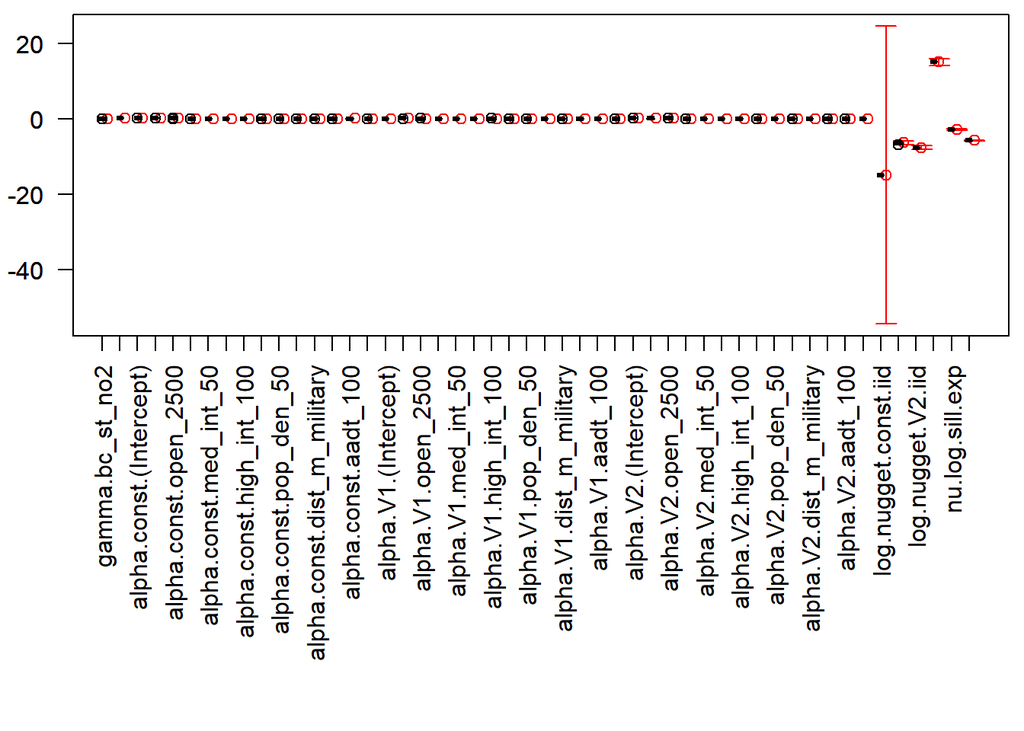

```r
par(mfrow=c(1,1), mar=c(13.5,2.5,.5,.5), las=2)
with(coef(est.denver.model.B, pars="all"),
     plotCI((1:length(par))+.3, par, uiw=1.96*sd,
             col=2, xlab="", xaxt="n", ylab=""))
boxplot(est.denver.B.cv, "all", boxwex=.4, col="grey", add=TRUE)
```

```r
#' Save the results as an .rdata object
save(denver.data.B, denver.model.B, est.denver.model.B, est.denver.B.cv,
     file = here::here("Results", "Denver_ST_Model_B.rdata"))
```

### 3.2.4 Prediction using the CV model

Making predictions using the CV model. Printing out the CV summary statistics as well

```r
pred.B.cv <- predictCV(denver.model.B, est.denver.B.cv, LTA = T)
pred.B.cv.log <- predictCV(denver.model.B, est.denver.B.cv,
                           LTA = T, transform="unbiased")

summary(pred.B.cv)
```

```
## Cross-validation predictions for STmodel with 10 CV-groups.
##   Predictions for 615 observations.
##   Temporal averages for 60 locations.
##
## RMSE:
##              EX.mu EX.mu.beta         EX
## obs     0.13657608 0.13657608 0.09221580
## average 0.07956453 0.07956453 0.06352353
##
## R2:
##             EX.mu EX.mu.beta        EX
## obs     0.5600219  0.5600219 0.7994178
## average 0.7249227  0.7249227 0.8246584
##
## Coverage of 95% prediction intervals:
##                EX
## obs     0.8796748
## average 0.7833333
```

```r
summary(pred.B.cv.log)
```

```
## Cross-validation predictions for STmodel with 10 CV-groups.
##   Predictions for 615 observations.
##   Temporal averages for 60 locations.
##
## RMSE:
##              EX.mu EX.mu.beta         EX    EX.pred
## obs     0.15735040 0.15735040 0.10491946 0.10496228
## average 0.09056214 0.09056214 0.07080109 0.07088575
##
## R2:
##             EX.mu EX.mu.beta        EX   EX.pred
## obs     0.6164788  0.6164788 0.8294838 0.8293445
## average 0.7807003  0.7807003 0.8659630 0.8656423
##
## Coverage of 95% prediction intervals:
##           EX.pred
## obs     0.8796748
## average 0.8000000
```

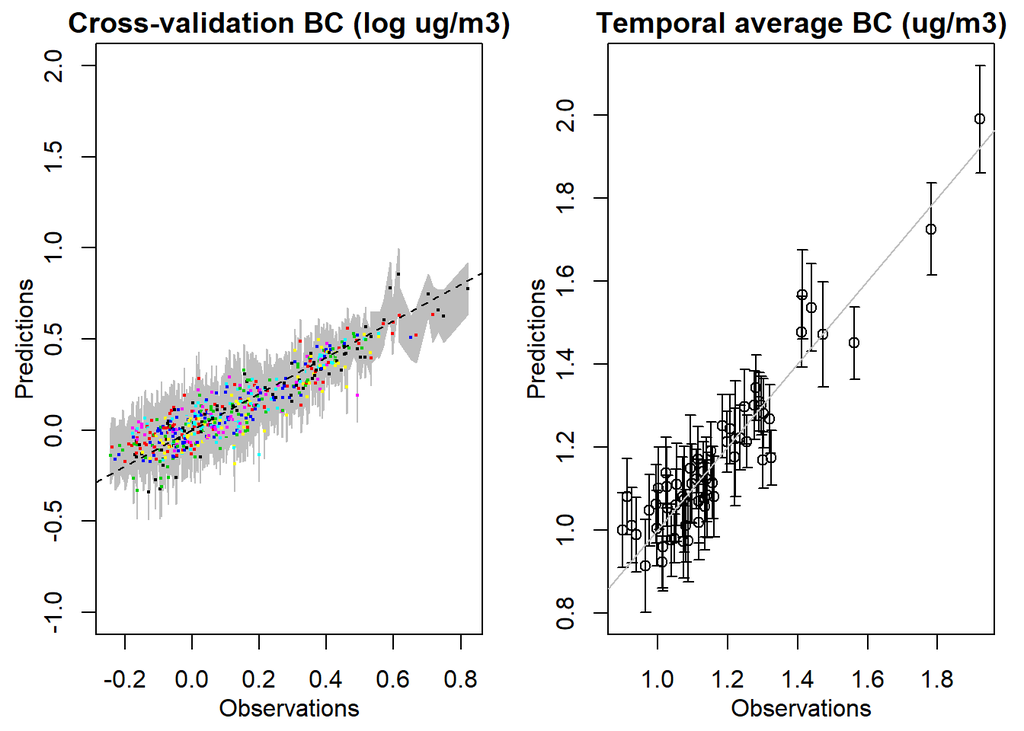

```r
par(mfrow=c(1,2), mar=c(3.3,3.3,1.5,1), mgp=c(2,1,0))
plot(pred.B.cv, "obs", ID="all", pch=c(19,NA), cex=.25, lty=c(NA,2),
     col=c("ID", "black", "grey"),
     ylim=c(-1,2),
     xlab="Observations", ylab="Predictions",
     main="Cross-validation BC (log ug/m3)")
with(pred.B.cv.log$pred.LTA, plotCI(obs, EX.pred, uiw=1.96*sqrt(VX.pred),
                                      xlab="Observations", ylab="Predictions",
                                      main="Temporal average BC (ug/m3)"))
abline(0, 1, col="grey")
```

```r
# jpeg(filename = here::here("Figs", "ST_CV_Obs_vs_Pred_BC_ModA.jpeg"),
#      width = 8, height = 4, units = "in", res = 500)
# par(mfrow=c(1,2), mar=c(3.3,3.3,1.5,1), mgp=c(2,1,0))
# plot(pred.B.cv, "obs", ID="all", pch=c(19,NA), cex=.25, lty=c(NA,2),
#      col=c("ID", "black", "grey"),
#      ylim=c(-1,2),
#      xlab="Observations", ylab="Predictions",
#      main="Cross-validation BC (log ug/m3)")
# with(pred.B.cv.log$pred.LTA, plotCI(obs, EX.pred, uiw=1.96*sqrt(VX.pred),
#                                       xlab="Observations", ylab="Predictions",
#                                       main="Temporal average BC (ug/m3)"))
# abline(0, 1, col="grey")
# dev.off()
```

### 3.2.5 Predictions for 2009-2019

What do the long-term predictions look like for this model? Predicting at the distributed (residential + community) sites

```r
x.B <- coef(est.denver.model.B, pars = "cov")$par
x.B
```

```
## [1] -15.000000  -6.433437  -7.656144  15.000000  -2.943827  -5.822055
```

```r
E.B <- predict(denver.model.B, est.denver.model.B, LTA = T,
               transform="unbiased", pred.var=FALSE)
print(E.B)
```

```
## Prediction for STmodel.
##
## Regression parameters:
##   0 Spatio-temporal covariate(s).
##   42 beta-fields regression parameters in x$pars.
##
## Regression parameters are assumed to be known and
##  prediction variances do NOT include
##  uncertainties in regression parameters.
##
## Prediction of beta-fields, (x$beta):
## List of 2
##  $ mu: num [1:61, 1:3] 0.112578 -0.031423 0.153037 0.000267 0.087846 ...
##   ..- attr(*, "dimnames")=List of 2
##  $ EX: num [1:61, 1:3] 0.11258 -0.03142 0.15304 0.00027 0.08783 ...
##   ..- attr(*, "dimnames")=List of 2
##
## Predictions for log-Gaussian field of type: unbiased
##
## Predictions for 521 times at 61 locations.
## List of 5
##  $ EX.mu     : num [1:521, 1:61] 1.63 1.56 1.68 1.54 1.52 ...
##   ..- attr(*, "dimnames")=List of 2
##  $ EX.mu.beta: num [1:521, 1:61] 1.68 1.61 1.72 1.57 1.55 ...
##   ..- attr(*, "dimnames")=List of 2
##  $ EX        : num [1:521, 1:61] 1.73 1.65 1.77 1.61 1.59 ...
##   ..- attr(*, "dimnames")=List of 2
##  $ EX.pred   : num [1:521, 1:61] 1.73 1.65 1.77 1.62 1.59 ...
##   ..- attr(*, "dimnames")=List of 2
##  $ log.EX    : num [1:521, 1:61] 0.519 0.474 0.544 0.451 0.438 ...
##   ..- attr(*, "dimnames")=List of 2
##
## Variances have been computed.
## List of 2
##  $ log.VX     : num [1:521, 1:61] 0.054 0.0538 0.0536 0.0534 0.0533 ...
##   ..- attr(*, "dimnames")=List of 2
##  $ log.VX.pred: num [1:521, 1:61] 0.057 0.0568 0.0565 0.0564 0.0562 ...
##   ..- attr(*, "dimnames")=List of 2
##
## Mean squared prediciton errors NOT been computed.
##
## 61 temporal averages have been compute.
## List of 1
##  $ LTA:'data.frame': 61 obs. of  4 variables:
```

```r
week_preds <- as.data.frame(E.B$EX) %>%
  mutate(week = as.Date(rownames(E.B$EX)),
         year = year(as.Date(rownames(E.B$EX))))

week_sites <- colnames(week_preds)[which(str_detect(colnames(week_preds), "d_"))]

box_preds <- week_preds %>%
  select(week, all_of(week_sites)) %>%
  #filter(week %in% week_weeks) %>%
  mutate(month = month(week),
         year = year(week)) %>%
  filter(year %in% c(2009:2019))

box_data <- box_preds %>%
  pivot_longer(-c(week, month, year), names_to = "location", values_to = "pred")
summary(box_data)
```

```
##       week                month            year        location
##  Min.   :2009-01-05   Min.   : 1.00   Min.   :2009   Length:31200
##  1st Qu.:2011-07-16   1st Qu.: 4.00   1st Qu.:2011   Class :character
##  Median :2014-01-09   Median : 7.00   Median :2014   Mode  :character
##  Mean   :2014-01-08   Mean   : 6.51   Mean   :2014
##  3rd Qu.:2016-07-05   3rd Qu.: 9.25   3rd Qu.:2016
##  Max.   :2018-12-31   Max.   :12.00   Max.   :2018
##
##       pred
##  Min.   :0.553
##  1st Qu.:1.217
##  Median :1.440
##  Mean   :1.500
##  3rd Qu.:1.758
##  Max.   :3.229
##  NA's   :480
```

```r
#' Box plot of weekly BC predicted at all distributed sites grouped by month
box_summary <- box_data %>%
  group_by(month) %>%
  summarize(median = median(pred, na.rm=T)) %>%
  arrange(desc(median))
box_summary
```

| month | median |
| --- | --- |
| 12 | 1.971721 |
| 1 | 1.842178 |
| 11 | 1.806171 |
| 2 | 1.736862 |
| 10 | 1.588456 |
| 3 | 1.481155 |
| 9 | 1.411916 |
| 8 | 1.324297 |
| 4 | 1.246209 |
| 7 | 1.206784 |

[output cut: 2 more lines]

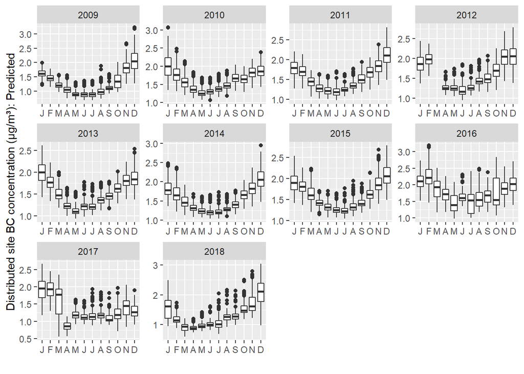

```r
pred_box_plot <- ggplot(box_data) +
  geom_boxplot(aes(x = as.factor(month), y = pred), #, color = as.factor(month)),
               show.legend = F) +
  #scale_color_viridis(name = "Month", discrete = T) +
  facet_wrap(. ~ year, scales = "free") +
  xlab("") + ylab("Distributed site BC concentration (\u03BCg/m\u00B3): Predicted") +
  # theme(axis.text.x = element_text(angle = 45, vjust = 1, hjust = 1)) +
  scale_x_discrete(labels = str_sub(month.name, 1, 1))
pred_box_plot
```

# 4 Summary Table

Summary of model diagnostics

| model | trend_data | cov_beta0 | cov_beta1 | cov_beta2 | cov_nu_error | no_basis_fns | df_per_year | all_converge | all_conv | cv_rmse_obs | cv_rmse_avg | cv_r2_obs | cv_r2_avg | cv_coverage_obs | cv_coverage_avg |
| --- | --- | --- | --- | --- | --- | --- | --- | --- | --- | --- | --- | --- | --- | --- | --- |
| Model A | BC + NO2 + PM2.5 | iid | iid | NA | exp | 1 | 4 | TRUE | TRUE | 0.11 | 0.07 | 0.81 | 0.86 | 0.90 | 0.85 |
| Model B | BC + NO2 + PM2.5 | iid | iid | iid | exp | 2 | 4 | TRUE | TRUE | 0.10 | 0.07 | 0.83 | 0.87 | 0.88 | 0.80 |